# Bat Echolocation

Capstone project: BIDA 302

Author

Valpreet Kaur

Published

November 26, 2025

## Introduction

Echolocation call data for 4 species of Vancouver Island bats (https://bcbats.ca/bat-basics/bat-species-in-bc/). Call data comprises 30 unique records for 4 echolocation call parameters for each of the bat species. Call data was recorded using an ultrasonic bat detector (Anabat; Titley Scientific https://www.titley-scientific.com/) with call parameters downloaded and extracted using AnaLook.

For this project, explore the data using the inspiration provided by the penguin analysis (below).

### Data source

Variables:

**Species**

EPFU - Eptesicus fuscus; Big Brown Bat

LACI - Lasiurus cinereus; Hoary Bat

MYLU - Myotis lucifugus; Little Brown Bat

MYVO - Myotis volans; Long-legged Myotis

**Filename** - Unique ID for each bat call

*Echolocation Call Paramters:*

**Time_Btw_Calls** - Time between calls (milliseconds)

**Duration** - Duration of the body of call (milliseconds)

**Frequency** - Characteristic frequency (kHz)

**Slope** - Characteristic slope

Source: Dr. Joanna Burgar; https://github.com/joburgar/Bat_Data

### Additional Inspiration

The R package {palmerpenguins} reference page has some tabulations and visualizations that may provide some inspiration:

- https://allisonhorst.github.io/palmerpenguins/
- in particular, the “Get started” and “Articles” have both the visualizations and the code used to create those visualizations.

## Other resources

**Statistical analysis of bat calls**

David W. Armitage and Holly K. Ober, A comparison of supervised learning techniques in the classification of bat echolocation calls, *Ecological Infomatics*, 2010, 5, 465:473.

Xing Chen, Jun Zhaob, Yan-hua Chen, Wei Zhoub, and Alice C.Hughes, [Automatic standardized processing and identification of tropical bat calls using deep learning approaches](https://www.sciencedirect.com/science/article/pii/S0006320719308961), *Biological Conservation*, January 2020, Vol.241, doi: 10.1016/j.biocon.2019.108269

Oisin MacAodha, Rory Gibb, Kate E. Barlow, et al., [Bat detective—Deep learning tools for bat acoustic signal detection](https://journals.plos.org/ploscompbiol/article?id=10.1371/journal.pcbi.1005995), *PLOS Computational Biology*, 2018-03-08, doi: 10.1371/journal.pcbi.1005995

Keisuke Masuda, Takanori Matsui, Dai Fukui, et al., [Bat species classification by echolocation call using a machine learning system](https://www.jstage.jst.go.jp/article/mammalianscience/57/1/57_19/_article), *Honyurui Kagaku (Mammalian Science)*, Volume 57 (2017) Issue 1. doi: 10.11238/mammalianscience.57.19

Peter Ommundsen,Cori Lausen, Laura Matthias, [First Acoustic Records of the Brazilian Free-Tailed Bat (Tadarida brasiliensis) In British Columbia](https://www.researchgate.net/publication/319424456_First_Acoustic_Records_of_the_Brazilian_Free-Tailed_Bat_Tadarida_brasiliensis_In_British_Columbia), September 2017, *Northwestern Naturalist*, 98(2):132-136, DOI: 10.1898/NWN16-24.1

Veronica Zamora-Gutierrez, Celia Lopez-Gonzalez, M. Cristina MacSwiney Gonzalez, et al., [Acoustic identification of Mexican bats based on taxonomic and ecological constraints on call design](https://besjournals.onlinelibrary.wiley.com/doi/pdf/10.1111/2041-210X.12556), *Methods in Ecology and Evolution* 2016, 7, 1082–1091. doi: 10.1111/2041-210X.12556

**Other bat communication**

Jason Daley, [Researchers “Translate” Bat Talk. Turns Out, They Argue—A Lot](https://getpocket.com/explore/item/researchers-translate-bat-talk-turns-out-they-argue-a-lot), *Smithsonian Magazine*, 2016-12-22.

# **Bat Echolocation Capstone Project**

In this project, we will import, tidy, visualize, and analyze the bat call data following an approach inspired by the Palmer Penguins dataset. there are four parameters measured in each call: **Time_Btw_Calls (ms), Duration (ms), Frequency (kHz) & Slope**

## **1. Data import**

here we are going to import the re data to be used for analysis in the project (**Bat_call_data.csv**)

```r
#import necessary libraries for this project
library(tidyverse) #for libraries like ggplot etc.
library(janitor)#for data cleaning
library(knitr)#for formated tables
```

Importig and reading the data into the project

```r
#import bat_call_data.csv data file
bat_call_data <- read_csv("Bat_Call_Data.csv")
##View the first few rows
head(bat_call_data)
```

```
# A tibble: 6 × 6
  Species Filename     Time_Btw_Calls Frequency Duration Slope
  <chr>   <chr>                 <dbl>     <dbl>    <dbl> <dbl>
1 EPFU    B6212118.46#            170        26        6    32
2 EPFU    B7122143.02#            218        26        7    24
3 EPFU    B7122201.58#            174        27        5    23
4 EPFU    B7122203.47#            275        26        7    29
5 EPFU    B7122231.29#            213        26        5    38
6 EPFU    B7192030.55#            145        27        3    38
```

```r
#structure of thedata
glimpse(bat_call_data)
```

```
Rows: 120
Columns: 6
$ Species        <chr> "EPFU", "EPFU", "EPFU", "EPFU", "EPFU", "EPFU", "EPFU",…
$ Filename       <chr> "B6212118.46#", "B7122143.02#", "B7122201.58#", "B71222…
$ Time_Btw_Calls <dbl> 170, 218, 174, 275, 213, 145, 181, 130, 128, 146, 398, …
$ Frequency      <dbl> 26, 26, 27, 26, 26, 27, 25, 28, 29, 25, 26, 29, 28, 26,…
$ Duration       <dbl> 6, 7, 5, 7, 5, 3, 3, 3, 4, 5, 7, 3, 4, 7, 6, 5, 5, 5, 5…
$ Slope          <dbl> 32, 24, 23, 29, 38, 38, 48, 55, 28, 44, 22, 42, 42, 18,…
```

## **2. Tidying & Manipulation**

In this step, I prepare the dataset so it is ready for analysis. This includes making sure the variable names are consistent, organizing the data in a clear way, checking for duplicate records.

### **Define variable types and clean names**

Change the variable types to suitable ones (changing the datatypes ) to help in data manipulation

```r
bat_call_data <- bat_call_data %>%
  clean_names() %>% ##function to clean names
  mutate(
    species = as.factor(species), #read spicieas as a factor
    filename = as.character(filename),#change filename to character type
    time_btw_calls = as.numeric(time_btw_calls),#change time_btwn calls tp numeric
    duration = as.numeric(duration),#change to numeric
    frequency = as.numeric(frequency),#change frequency to numeric
    slope = as.numeric(slope)#change the slopeto numeric
  )
#see the changes made in the structure
glimpse(bat_call_data)
```

```
Rows: 120
Columns: 6
$ species        <fct> EPFU, EPFU, EPFU, EPFU, EPFU, EPFU, EPFU, EPFU, EPFU, E…
$ filename       <chr> "B6212118.46#", "B7122143.02#", "B7122201.58#", "B71222…
$ time_btw_calls <dbl> 170, 218, 174, 275, 213, 145, 181, 130, 128, 146, 398, …
$ frequency      <dbl> 26, 26, 27, 26, 26, 27, 25, 28, 29, 25, 26, 29, 28, 26,…
$ duration       <dbl> 6, 7, 5, 7, 5, 3, 3, 3, 4, 5, 7, 3, 4, 7, 6, 5, 5, 5, 5…
$ slope          <dbl> 32, 24, 23, 29, 38, 38, 48, 55, 28, 44, 22, 42, 42, 18,…
```

### **remove duplicat records**

```r
#find duplicates from the dataset
dup_data <- bat_call_data %>% duplicated()

#remove duplcat records fromthe dataset
bat_call_data <- bat_call_data %>% distinct()
```

```r
#sort by species and filename for easier view
bat_call_data <- bat_call_data %>% arrange(species, filename)
#first few rows of sorted data
head(bat_call_data)
```

```
# A tibble: 6 × 6
  species filename     time_btw_calls frequency duration slope
  <fct>   <chr>                 <dbl>     <dbl>    <dbl> <dbl>
1 EPFU    B6212118.46#            170        26        6    32
2 EPFU    B7122143.02#            218        26        7    24
3 EPFU    B7122201.58#            174        27        5    23
4 EPFU    B7122203.47#            275        26        7    29
5 EPFU    B7122231.29#            213        26        5    38
6 EPFU    B7192030.55#            145        27        3    38
```

### *Summary statistics for each call parameter in a summary table*

computing the mean, standard deviation, minimum, and maximum values each of the species in the dataset.

```r
##function to calculate summary statistics by species
summarize_by_species <- function(data) {
  data %>%
    group_by(species) %>%
    summarise(
      mean_duration   = mean(duration, na.rm = TRUE),
      sd_duration     = sd(duration, na.rm = TRUE),
      mean_frequency  = mean(frequency, na.rm = TRUE),
      sd_frequency    = sd(frequency, na.rm = TRUE),
      mean_time_btw   = mean(time_btw_calls, na.rm = TRUE),
      sd_time_btw     = sd(time_btw_calls, na.rm = TRUE),
      mean_slope      = mean(slope, na.rm = TRUE),
      sd_slope        = sd(slope, na.rm = TRUE)
    )
}
## generate the summary table usig the funcion
summary_stats <- summarize_by_species(bat_call_data)

#display the sumary table
summary_stats
```

```
# A tibble: 4 × 9
  species mean_duration sd_duration mean_frequency sd_frequency mean_time_btw
  <fct>           <dbl>       <dbl>          <dbl>        <dbl>         <dbl>
1 EPFU             4.63       1.40            27.1         1.14          209.
2 LACI             5.83       1.26            19.1         1.88          442.
3 MYLU             2          0.910           39.2         1.89          274.
4 MYVO             2.03       0.615           37.6         1.59          277.
# ℹ 3 more variables: sd_time_btw <dbl>, mean_slope <dbl>, sd_slope <dbl>
```

## **3. Visualizations**

### **Tables**

**Summary table**

```r
#function create sumary table with selected statistics for species
create_species_summary <- function(data) {
  data %>%
    group_by(species) %>%
    summarise(
      n = n(),
      mean_duration = mean(duration, na.rm = TRUE),
      mean_frequency = mean(frequency, na.rm = TRUE),
      mean_time_btw_calls = mean(time_btw_calls, na.rm = TRUE),
      mean_slope = mean(slope, na.rm = TRUE)
    )
}
#generate the summary table using the function
summary_table <- create_species_summary(bat_call_data)

##display table output
kable(summary_table,caption = "Summary Statistics for Each Bat Species")
```

Summary Statistics for Each Bat Species

| species | n | mean_duration | mean_frequency | mean_time_btw_calls | mean_slope |
| --- | --- | --- | --- | --- | --- |
| EPFU | 30 | 4.633333 | 27.06667 | 209.4333 | 36.50000 |
| LACI | 30 | 5.833333 | 19.10000 | 441.6333 | 15.13333 |
| MYLU | 30 | 2.000000 | 39.23333 | 273.9000 | 66.53333 |
| MYVO | 30 | 2.033333 | 37.60000 | 276.8333 | 96.96667 |

The table indicates a distinct difference in the features of average echolocation calls of the four bat species. LACI has the longest average call duration and the highest time between calls whereas MYLU and MYVO generate relatively short calls. MYLU has the largest average call frequency with MYVO coming very close and LACI has the least. MYVO demonstrates the sharpest average slope, which means that the changes in call structure are more rapid. The variations are indicative of the fact that every species applies echolocation differently.

### **Plots**

#### **Scatterplots**

**Frequency vs Duration**

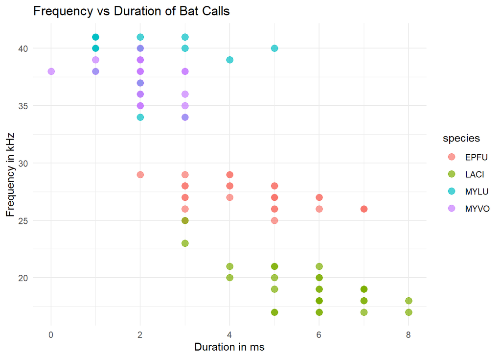

```r
#plot of frequncy vs duration of the spcies
bat_call_data %>%
  ggplot(aes(x = duration, y = frequency, color = species)) +
  geom_point(size = 3, alpha = 0.7) +
  labs(
    title = "Frequency vs Duration of Bat Calls",##plot title
    x = "Duration in ms",
    y = "Frequency in kHz"
  ) +
  theme_minimal()
```

**Discussion**

This scatter plot shows that each bat species has its own unique range of call frequency and duration. LACI produces low-frequency calls, which travel farther and are better suited for open spaces. MYLU and MYVO use much higher-frequency and shorter calls, which work well in dense habitats such as forests where detailed navigation is needed, even though the sound does not travel very far. EPFU falls between these groups in both frequency and duration. The small areas where the species overlap suggest that bats have adapted their calls to reduce competition and allow different species to hunt in different environments without interfering with each other.

**Time Between Calls vs Frequency**

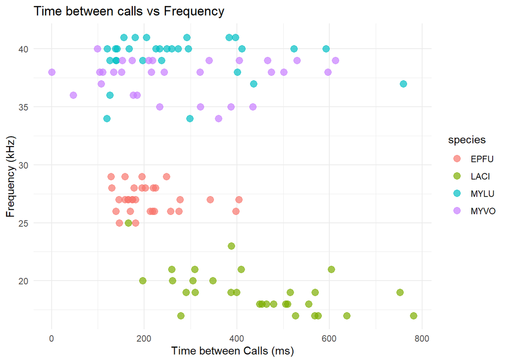

```r
bat_call_data %>%
  ggplot(aes(x = time_btw_calls, y = frequency, color = species)) +
  geom_point(size = 3, alpha = 0.7) +
  labs(
    title = "Time between calls vs Frequency",
    x = "Time between Calls (ms)",
    y = "Frequency (kHz)"
  ) +
  theme_minimal()
```

**Discussion**

This scatter plot shows that each bat species usually uses a specific call frequency, but the time between calls can change a lot depending on what the bat is doing. All four species can adjust how fast they call, even though they operate at different frequencies. This is especially important during hunting. When a bat is searching over long distances, it sends out calls more slowly. As it gets closer to its target, the calls become much faster to track the prey’s movement more accurately. These results suggest that all four species are able to adjust their echolocation effectively to meet their hunting and navigation needs.

#### **Density Plot**

**Frequency Distribution for All Species**

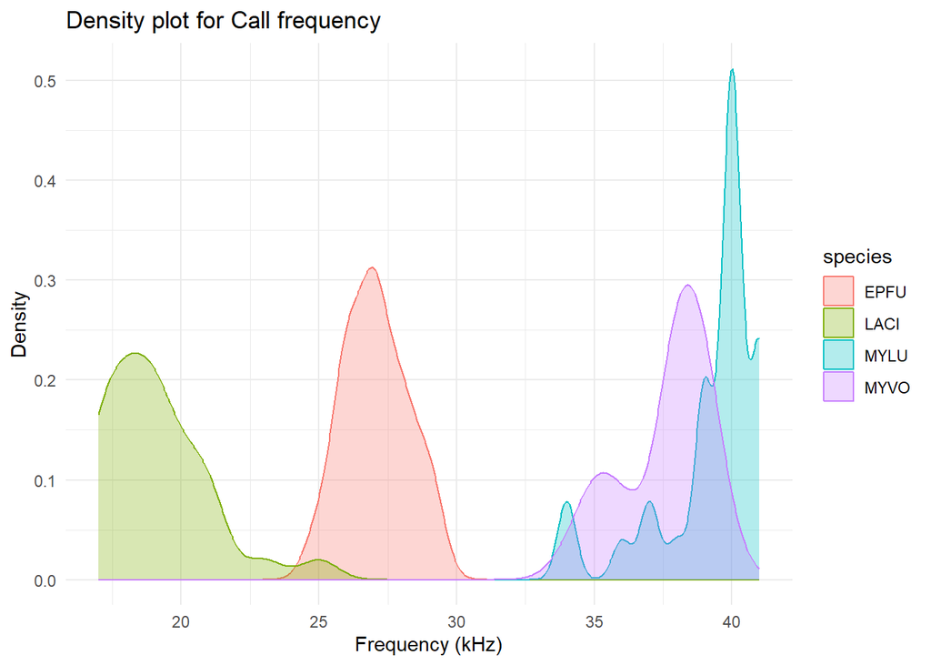

```r
bat_call_data %>%
  ggplot(aes(x = frequency, color = species, fill = species)) +
  geom_density(alpha = 0.3) +
  labs(
    title = "Density plot for Call frequency",
    x = "Frequency (kHz)",
    y = "Density"
  ) +
  theme_minimal()
```

## **4. Model: Simple classification model**

### **Multiclass logistic regression model**

**Load Package**

```r
##Load needed package logistic regression
library(nnet)
```

**split data for training and testing**

```r
#spliting the data into training and testing
set.seed(123)

#training index (70% train data and 30% test)
training_index <- sample(1:nrow(bat_call_data), size = 0.7 * nrow(bat_call_data))

##Split into training and test sets
training_data <- bat_call_data[training_index, ]
testing_data  <- bat_call_data[-training_index, ]
```

**Fit the model**

```r
##fit multinomial logistic regression with all the 4 numric parameters
model <- multinom(
  species ~ duration + frequency + time_btw_calls + slope,
  data = training_data
)
summary(model)
```

```
Call:
multinom(formula = species ~ duration + frequency + time_btw_calls +
    slope, data = training_data)

Coefficients:
     (Intercept)   duration frequency time_btw_calls      slope
LACI    110.7771  -6.192466 -2.748380    0.030259836 -0.8527483
MYLU   -114.5860 -11.462333  4.898844    0.009345270 -0.2759618
MYVO   -106.1841 -10.606943  4.502630    0.008006015 -0.2051634

Std. Errors:
     (Intercept)  duration frequency time_btw_calls    slope
LACI  0.08029702 0.1774123  2.178776      0.3965760 2.280517
MYLU  0.09530944 0.4579032  3.105263      0.2575087 1.892091
MYVO  0.10082715 0.4584642  3.104908      0.2575011 1.891962

Residual Deviance: 41.01872
AIC: 71.01872
```

**Make predictions**

```r
#make predictions of the species on test data
predicted_species <- predict(model, newdata = testing_data)

#compare predictions on the actual species
predicted_species
```

```
 [1] EPFU EPFU EPFU EPFU EPFU EPFU EPFU EPFU EPFU EPFU EPFU EPFU LACI LACI LACI
[16] LACI LACI LACI LACI MYLU MYLU MYLU MYLU MYLU MYLU MYLU MYLU MYVO MYVO MYVO
[31] MYVO MYLU MYVO MYVO MYVO EPFU
Levels: EPFU LACI MYLU MYVO
```

Evaluate model accuracy

```r
## model accuracy
accuracy <- mean(predicted_species == testing_data$species)
accuracy
```

```
[1] 0.8888889
```

Confusion matrix

```r
table(
  Actual = testing_data$species,
  Predicted = predicted_species
)
```

```
      Predicted
Actual EPFU LACI MYLU MYVO
  EPFU   11    0    0    0
  LACI    1    7    0    0
  MYLU    0    0    8    1
  MYVO    1    0    1    6
```

#### **Model Results**

*Prediction Accuracy*  
The model achieved an accuracy of *88.9%*, meaning it correctly predicted the bat species for most of the test data. This shows that even a simple classification model can perform well using basic echolocation features.

*Confusion Matrix Interpretation*  
EPFU was classified perfectly, with all 11 test cases predicted correctly. LACI also showed strong performance, with only one misclassification. MYLU and MYVO showed a small amount of confusion between them, which is expected since these two species share similar echolocation characteristics.

## **Conclusion**

This was a project that investigated bat echolocation calls in order to know the difference between species level and construct a simplified predictive model. Visual analysis, data cleaning, and classification presented significant patterns of call frequency, duration, and Interorder intervals between calls, which were well justified by ecological anticipated patterns. There were also overlapping acoustic ranges of some species and this could have affected the classification outcome.

An approximation of 88.9 percent accuracy was obtained using a multinomial logistic regression model indicating that even a simple model can be used to predict species using a small dataset. On the whole, the project has shown that the acoustic features can be used to differentiate bat species and statistical modeling can be used to facilitate automated recognition of species. The developed workflow is a strong basis of further research using more massive data and models.